# Multiclass Classification

Zifeng Zhao

week 06 session 02

In this lab, we will practice implementing multinomial logistic regression and multiclass neural networks in `R`.

## 1. Car Selection Dataset

### 1.1 Data Partition

Let’s read in the data stored in `Car_Selection.csv` and check the distribution of the three classes in the dependent variable `Car`.

```r
rm(list=ls())
library(caret)
total_data <- read.csv('./Car_Selection.csv', stringsAsFactors=T)
table(total_data$Car)/dim(total_data)[1]
```

```
##
##       reg       suv       van
## 0.5354534 0.2771809 0.1873657
```

We further do a 60%-40% training-test split. To perform a stratified sampling, we use the `createDataPartition()` function in the `R` package `caret`. We use the `set.seed()` function in `R` to control the randomness of the training-test split. Let’s recheck the distribution of the three classes in the dependent variable `Car` in the `train_data` and `test_data`.

```r
set.seed(7)
train_index <- createDataPartition(y=total_data$Car, p=0.6, list=F)
train_data <- total_data[train_index,]
test_data <- total_data[-train_index,]
table(train_data$Car)/dim(train_data)[1]
```

```
##
##       reg       suv       van
## 0.5354331 0.2770222 0.1875447
```

```r
table(test_data$Car)/dim(test_data)[1]
```

```
##
##       reg       suv       van
## 0.5354839 0.2774194 0.1870968
```

### 1.2 Multinomial logistic regression

We build a multinomial logistic regression model for the dependent variable `Car` with all predictors `College+Household+Commute+Income` based on the **training** data using the function `multinom()` in the `R` package `nnet` and name it `lm1`.

```r
library(nnet)
lm1 <- multinom(Car~College+Household+Commute+Income, data=train_data)
summary(lm1)
```

```
## Call:
## multinom(formula = Car ~ College + Household + Commute + Income,
##     data = train_data)
##
## Coefficients:
##     (Intercept)   College Household    Commute    Income
## suv   -20.11652 12.941424  7.297619 -13.140157 0.1400884
## van   -19.32050  6.745615 14.078743  -7.051779 0.1397657
##
## Std. Errors:
##     (Intercept)   College Household   Commute      Income
## suv    1.019428 0.7178207 0.6990466 0.6728439 0.007122149
## van    1.009190 0.5576506 0.7540329 0.5748272 0.007372053
##
## Residual Deviance: 1247.202
## AIC: 1267.202
```

### 1.3 Model evaluation

Let’s evaluate the prediction performance of `lm1` on the test data. We use the `confusionMatrix()` function in the `R` package `caret` to automatically generate the error metrics such as accuracy, sensitivity and specificity.

```r
class_labels <- levels(train_data$Car)
lm1_pred <- predict(lm1, newdata=test_data, type='probs')
lm1_pred_class <- factor(class_labels[apply(lm1_pred, 1, which.max)])
lm1_acc <- confusionMatrix(lm1_pred_class, reference=test_data$Car)
lm1_acc
```

```
## Confusion Matrix and Statistics
##
##           Reference
## Prediction reg suv van
##        reg 941  51  13
##        suv  31 401   1
##        van  24  64 334
##
## Overall Statistics
##
##                Accuracy : 0.9011
##                  95% CI : (0.8866, 0.9143)
##     No Information Rate : 0.5355
##     P-Value [Acc > NIR] : < 2.2e-16
##
##                   Kappa : 0.8361
##
##  Mcnemar's Test P-Value : 6.301e-15
##
## Statistics by Class:
##
##                      Class: reg Class: suv Class: van
## Sensitivity              0.9448     0.7771     0.9598
## Specificity              0.9259     0.9762     0.9418
## Pos Pred Value           0.9363     0.9261     0.7915
## Neg Pred Value           0.9357     0.9194     0.9903
## Prevalence               0.5355     0.2774     0.1871
## Detection Rate           0.5059     0.2156     0.1796
## Detection Prevalence     0.5403     0.2328     0.2269
## Balanced Accuracy        0.9354     0.8767     0.9508
```

## 2. MNIST Digit Dataset

### 2.1 Data Partition and Visualization

Let’s read in the data stored in `MNIST_Digit.csv` and perform some data visualization.

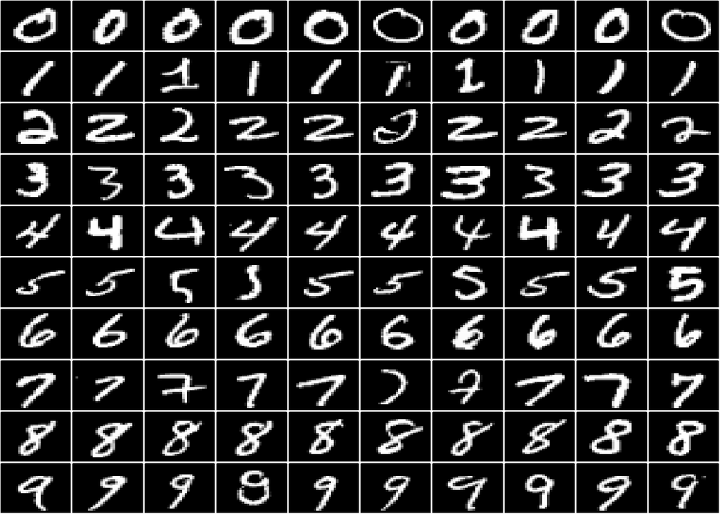

```r
rm(list=ls())
total_data0 <- read.csv("./MNIST_Digit.csv", header=F)
colnames(total_data0) <- c('digit', paste0('v',1:784))

par(mfrow=c(10,10))
plot_margin <- 0.1
par(mar=c(plot_margin, plot_margin, plot_margin, plot_margin), xaxt='n', yaxt='n')
for(digit_index in 0:9){
  tmp_data <- total_data0[total_data0$digit==digit_index,]
  for(sample_index in 1:10){
    tmp_image <- as.numeric(tmp_data[sample_index,])
    image(matrix(tmp_image[-1], nrow=28, byrow=F)[,28:1], col=gray((0:255)/255))
  }
}
```

To ease computational burden, let’s focus on the classification of digit 1,2,3. In other words, we perform a three-class classification. Let’s also check the distribution of the three classes (1,2,3) in the dependent variable `digit`.

```r
total_data <- total_data0[total_data0$digit%in%c(1,2,3),]
total_data$digit <- factor(total_data$digit)
dim(total_data)
```

```
## [1] 9424  785
```

```r
table(total_data$digit)/dim(total_data)[1]
```

```
##
##         1         2         3
## 0.3578098 0.3132428 0.3289474
```

We further do a 50%-50% training-test split from the very beginning. To perform a stratified sampling, we use the `createDataPartition()` function in the `R` package `caret`. We use the `set.seed()` function in `R` to control the randomness of the training-test split. Let’s recheck the distribution of the three classes in the dependent variable `digit` in the `train_data` and `test_data`.

```r
set.seed(7)
train_index <- createDataPartition(total_data$digit, p=0.5, list=F)
train_data <- total_data[train_index,]
test_data <- total_data[-train_index,]
table(train_data$digit)/dim(train_data)[1]
```

```
##
##         1         2         3
## 0.3578098 0.3132428 0.3289474
```

```r
table(test_data$digit)/dim(test_data)[1]
```

```
##
##         1         2         3
## 0.3578098 0.3132428 0.3289474
```

### 2.2 Multinomial logistic regression

We build a multinomial logistic regression model for the dependent variable `digit` with all 784 pixel predictors based on the **training** data using the function `multinom()` in the `R` package `nnet` and name it `lm1`. We set the argument `MaxNWts=10000` in the `multinom()` function to make sure the model can be implemented.

```r
library(nnet)
lm1 <- multinom(digit~., data=train_data, MaxNWts=10000)
```

### 2.3 Multiclass neural networks

We further build a neural networks for the dependent variable `digit` with all 784 pixel predictors based on the **training** data. We first need to reformat the training data and store it in `x_train_nn`. We then standardize all predictors $X$ in the data frame `x_train_nn` by dividing with the maximum value possible (255) and combine the data frame with the dependent variable. We do the same thing to obtain the reformatted test data `x_test_nn`.

```r
x_train_nn <- model.matrix(digit~., data=train_data)[,-1]
x_train_nn <- x_train_nn/255

x_train_nn <- cbind.data.frame(train_data$digit, x_train_nn)
colnames(x_train_nn)[1] <- 'digit'

x_test_nn <- model.matrix(digit~., data=test_data)[,-1]
x_test_nn <- x_test_nn/255
```

We now build an NN with all predictors available and store it in `nn1`. For the architecture of `nn1`, let’s have one hidden layer with 4 hidden units and keep the activation function as sigmoid. Note that there is randomness in the training of NN due to the random initialization of the optimization. Thus we use `set.seed()` to control the randomness and ensure reproducibility. We can use `plot()` function to visualize the estimated NN, however, it is difficult to interpret the estimated model.

```r
library(neuralnet)
set.seed(7)
nn1 <- neuralnet(digit~., data=x_train_nn, linear.output=F, hidden=4)
# plot(nn1)
```

### 2.4 Model evaluation

Let’s evaluate the prediction performance of `lm1` and `nn1` on the test data. We use the `confusionMatrix()` function in the `R` package `caret` to automatically generate the error metrics such as accuracy, sensitivity and specificity.

```r
class_labels <- levels(train_data$digit)
# lm1
lm1_pred <- predict(lm1, newdata=test_data, type='probs')
lm1_pred_class <- factor(class_labels[apply(lm1_pred, 1, which.max)])
lm1_acc <- confusionMatrix(lm1_pred_class, reference=test_data$digit)
lm1_acc
```

```
## Confusion Matrix and Statistics
##
##           Reference
## Prediction    1    2    3
##          1 1639  124   84
##          2   18 1241  136
##          3   29  111 1330
##
## Overall Statistics
##
##                Accuracy : 0.8935
##                  95% CI : (0.8843, 0.9021)
##     No Information Rate : 0.3578
##     P-Value [Acc > NIR] : < 2.2e-16
##
##                   Kappa : 0.8396
##
##  Mcnemar's Test P-Value : < 2.2e-16
##
## Statistics by Class:
##
##                      Class: 1 Class: 2 Class: 3
## Sensitivity            0.9721   0.8408   0.8581
## Specificity            0.9313   0.9524   0.9557
## Pos Pred Value         0.8874   0.8896   0.9048
## Neg Pred Value         0.9836   0.9292   0.9321
## Prevalence             0.3578   0.3132   0.3289
## Detection Rate         0.3478   0.2634   0.2823
## Detection Prevalence   0.3920   0.2961   0.3120
## Balanced Accuracy      0.9517   0.8966   0.9069
```

```r
# nn1
nn1_pred <- predict(nn1, newdata=x_test_nn, type='response')
nn1_pred_class <- factor(class_labels[apply(nn1_pred, 1, which.max)])
nn1_acc <- confusionMatrix(nn1_pred_class, reference=test_data$digit)
nn1_acc
```

```
## Confusion Matrix and Statistics
##
##           Reference
## Prediction    1    2    3
##          1 1619   28   30
##          2   32 1418   89
##          3   35   30 1431
##
## Overall Statistics
##
##                Accuracy : 0.9482
##                  95% CI : (0.9415, 0.9544)
##     No Information Rate : 0.3578
##     P-Value [Acc > NIR] : < 2.2e-16
##
##                   Kappa : 0.9222
##
##  Mcnemar's Test P-Value : 1.446e-06
##
## Statistics by Class:
##
##                      Class: 1 Class: 2 Class: 3
## Sensitivity            0.9603   0.9607   0.9232
## Specificity            0.9808   0.9626   0.9794
## Pos Pred Value         0.9654   0.9214   0.9566
## Neg Pred Value         0.9779   0.9817   0.9630
## Prevalence             0.3578   0.3132   0.3289
## Detection Rate         0.3436   0.3009   0.3037
## Detection Prevalence   0.3559   0.3266   0.3175
## Balanced Accuracy      0.9705   0.9617   0.9513
```

Let’s visually inspect which image is wrongly classified by neural networks.

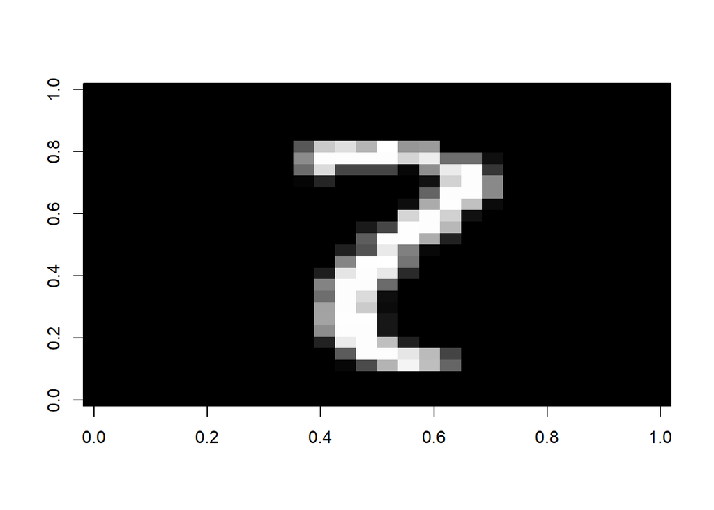

```r
err_index <- which(nn1_pred_class!=test_data$digit)
tmp_image <- as.numeric(test_data[46,])
image(matrix(tmp_image[-1], nrow=28, byrow=F)[,28:1], col=gray((0:255)/255))
```

```r
nn1_pred_class[46]
```

```
## [1] 1
## Levels: 1 2 3
```

```r
test_data$digit[46]
```

```
## [1] 2
## Levels: 1 2 3
```

## 3. In-class Exercise: MNIST Fashion Dataset

### 3.1 Data Partition and Visualization

Let’s read in the data stored in `MNIST_Fashion.csv` and perform some data visualization.

[figure not shown]

```r
rm(list=ls())
total_data0 <- read.csv("./MNIST_Fashion.csv", header=F)
colnames(total_data0) <- c('type', paste0('v',1:784))

par(mfrow=c(10,10))
plot_margin <- 0.1
par(mar=c(plot_margin, plot_margin, plot_margin, plot_margin), xaxt='n', yaxt='n')
for(type_index in 0:9){
  tmp_data <- total_data0[total_data0$type==type_index,]
  for(sample_index in 1:10){
    tmp_image <- as.numeric(tmp_data[sample_index,])
    image(matrix(tmp_image[-1], nrow=28, byrow=F)[,28:1], col=gray((0:255)/255))
  }
}
```

To ease computational burden, let’s focus on the classification of type 0,1,2. In other words, we perform a three-class classification. Let’s also check the distribution of the three classes (0,1,2) in the dependent variable `type`.

```r
total_data <- total_data0[total_data0$type%in%c(0,1,2),]
total_data$type <- factor(total_data$type)
dim(total_data)
```

```
## [1] 9000  785
```

```r
table(total_data$type)/dim(total_data)[1]
```

```
##
##         0         1         2
## 0.3333333 0.3333333 0.3333333
```

We further do a 25%-75% training-test split from the very beginning. To perform a stratified sampling, we use the `createDataPartition()` function in the `R` package `caret`. We use the `set.seed()` function in `R` to control the randomness of the training-test split. Let’s recheck the distribution of the three classes in the dependent variable `type` in the `train_data` and `test_data`.

```r
set.seed(7)
train_index <- createDataPartition(total_data$type, p=0.25, list=F)
train_data <- total_data[train_index,]
test_data <- total_data[-train_index,]
table(train_data$type)/dim(train_data)[1]
```

```
##
##         0         1         2
## 0.3333333 0.3333333 0.3333333
```

```r
table(test_data$type)/dim(test_data)[1]
```

```
##
##         0         1         2
## 0.3333333 0.3333333 0.3333333
```

### 3.2 Multinomial logistic regression

We build a multinomial logistic regression model for the dependent variable `type` with all 784 pixel predictors based on the **training** data using the function `multinom()` in the `R` package `nnet` and name it `lm1`. We set the argument `MaxNWts=10000` in the `multinom()` function to make sure the model can be implemented.

```r
library(nnet)
lm1 <- multinom(type~., data=train_data, MaxNWts=10000)
```

### 3.3 Multiclass neural networks

```r
x_train_nn <- model.matrix(type~., data=train_data)[,-1]
x_train_nn <- x_train_nn/255

x_train_nn <- cbind.data.frame(train_data$type, x_train_nn)
colnames(x_train_nn)[1] <- 'type'

x_test_nn <- model.matrix(type~., data=test_data)[,-1]
x_test_nn <- x_test_nn/255
```

We now build an NN with all predictors available and store it in `nn1`. For the architecture of `nn1`, let’s have one hidden layer with 4 hidden units and keep the activation function as sigmoid. Note that there is randomness in the training of NN due to the random initialization of the optimization. Thus we use `set.seed()` to control the randomness and ensure reproducibility. We can use `plot()` function to visualize the estimated NN, however, it is difficult to interpret the estimated model.

```r
library(neuralnet)
set.seed(7)
nn1 <- neuralnet(type~., data=x_train_nn, linear.output=F, hidden=4)
# plot(nn1)
```

### 3.4 Model evaluation

Let’s evaluate the prediction performance of `lm1` and `nn1` on the test data. We use the `confusionMatrix()` function in the `R` package `caret` to automatically generate the error metrics such as accuracy, sensitivity and specificity.

```r
class_labels <- levels(train_data$type)
# lm1
lm1_pred <- predict(lm1, newdata=test_data, type='probs')
lm1_pred_class <- factor(class_labels[apply(lm1_pred, 1, which.max)])
lm1_acc <- confusionMatrix(lm1_pred_class, reference=test_data$type)
lm1_acc
```

```
## Confusion Matrix and Statistics
##
##           Reference
## Prediction    0    1    2
##          0 2064  113  228
##          1   64 2088   40
##          2  122   49 1982
##
## Overall Statistics
##
##                Accuracy : 0.9087
##                  95% CI : (0.9016, 0.9155)
##     No Information Rate : 0.3333
##     P-Value [Acc > NIR] : < 2.2e-16
##
##                   Kappa : 0.8631
##
##  Mcnemar's Test P-Value : 4.274e-10
##
## Statistics by Class:
##
##                      Class: 0 Class: 1 Class: 2
## Sensitivity            0.9173   0.9280   0.8809
## Specificity            0.9242   0.9769   0.9620
## Pos Pred Value         0.8582   0.9526   0.9206
## Neg Pred Value         0.9572   0.9645   0.9417
## Prevalence             0.3333   0.3333   0.3333
## Detection Rate         0.3058   0.3093   0.2936
## Detection Prevalence   0.3563   0.3247   0.3190
## Balanced Accuracy      0.9208   0.9524   0.9214
```

```r
# nn1
nn1_pred <- predict(nn1, newdata=x_test_nn, type='response')
nn1_pred_class <- factor(class_labels[apply(nn1_pred, 1, which.max)])
nn1_acc <- confusionMatrix(nn1_pred_class, reference=test_data$type)
nn1_acc
```

```
## Confusion Matrix and Statistics
##
##           Reference
## Prediction    0    1    2
##          0 2154   30   76
##          1   35 2202   35
##          2   61   18 2139
##
## Overall Statistics
##
##                Accuracy : 0.9622
##                  95% CI : (0.9574, 0.9666)
##     No Information Rate : 0.3333
##     P-Value [Acc > NIR] : < 2e-16
##
##                   Kappa : 0.9433
##
##  Mcnemar's Test P-Value : 0.05808
##
## Statistics by Class:
##
##                      Class: 0 Class: 1 Class: 2
## Sensitivity            0.9573   0.9787   0.9507
## Specificity            0.9764   0.9844   0.9824
## Pos Pred Value         0.9531   0.9692   0.9644
## Neg Pred Value         0.9786   0.9893   0.9755
## Prevalence             0.3333   0.3333   0.3333
## Detection Rate         0.3191   0.3262   0.3169
## Detection Prevalence   0.3348   0.3366   0.3286
## Balanced Accuracy      0.9669   0.9816   0.9666
```

Let’s visually inspect which image is wrongly classified by neural networks.

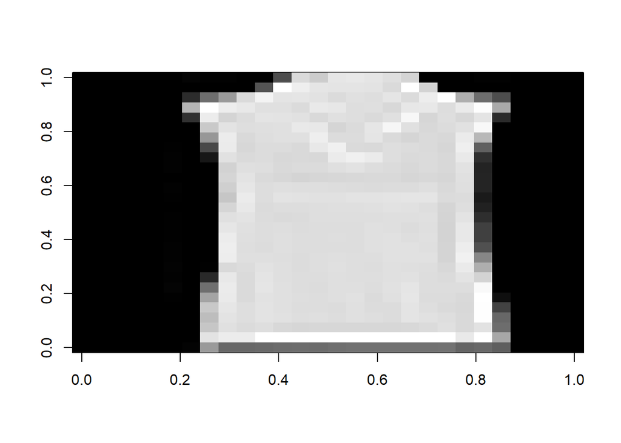

```r
err_index <- which(nn1_pred_class!=test_data$type)
tmp_image <- as.numeric(test_data[57,])
image(matrix(tmp_image[-1], nrow=28, byrow=F)[,28:1], col=gray((0:255)/255))
```

```r
nn1_pred_class[57]
```

```
## [1] 2
## Levels: 0 1 2
```

```r
test_data$type[57]
```

```
## [1] 0
## Levels: 0 1 2
```